# Differential Expression Analysis

One of the objective of the NeoSpan Dashboard is to evaluate the impact of the neoantigens on gene expression values. For this purpose, a well-known technique is the differential expression analysis (DEA) between neoantigen-positive and negative spots (i.e. spots that display or not the gene mutations associated with the potential neoantigens). There are several methodologies for DEA, which can be distinguished in 3 primary categories:

1. Group comparison tests.
2. Generalized linear models (excluding the traditional linear regression).
3. Zero-inflation models. Designed for data with many zero counts.

The Group comparison tests include the Student's t-test, the Wilcoxon Signed Rank test and the Bimodal test.The Generalized linear models include the Negative-binomial, the Poisson and the Logistic Regression. As for the zero-inflastion models, those include the MAST methodology.

In this dashboard, the user can choose the methodology to conduct. The output includes a dynamic table along with a dynamic volcano plot.

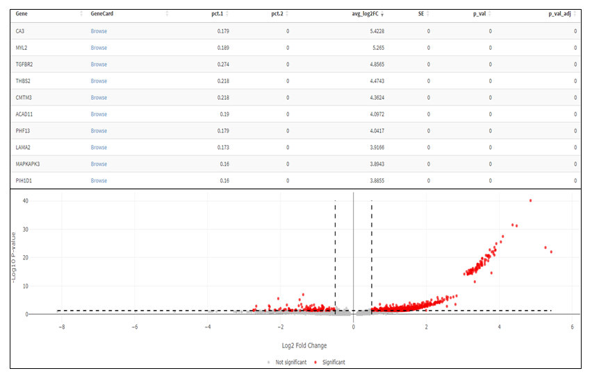

**Note**: DEA should only be utilized in datasets that have undergone the quality control and normalization.